# cw1

rodion

8 апреля 2017 г

```r
library(DESeq2)
library(ggplot2)
library(clusterProfiler)
library(org.Hs.eg.db)
library(pheatmap)
library(plotly)
library(GSE)
library(gridExtra)
library(dplyr)
library(VennDiagram)
library(amap)
library(dbscan)
options(width=120)
```

## Файлы с которыми будем работать сегодня

```r
conditions <- read.csv("GSE89633_conditions.tsv", sep="\t", header=1, row.names = 1, quote="")
counts <- read.csv("GSE89633_counts.tsv", sep="\t", header=1, row.names = 1, quote="")


print(counts[1:6, 1:2])
```

```
##           Sample_B.bam Sample_BB.bam
## 100009600           33            14
## 100009609            0             0
## 100009614            0             0
## 100009664            0             0
## 100012               0             0
## 100017             195           323
```

```r
dim(counts)
```

```
## [1] 24393    20
```

```r
head(counts)
```

```
##           Sample_B.bam Sample_BB.bam Sample_D.bam Sample_DD.bam Sample_F.bam Sample_FF.bam Sample_G.bam Sample_H.bam
## 100009600           33            14           29            19           19            16           14           24
## 100009609            0             0            0             0            0             0            0            0
## 100009614            0             0            0             0            0             0            0            0
## 100009664            0             0            0             0            0             0            0            0
## 100012               0             0            0             0            0             0            0            0
## 100017             195           323          138           321           96           240          104          145
##           Sample_HH.bam Sample_J.bam Sample_JJ.bam Sample_KK.bam Sample_L.bam Sample_LL.bam Sample_N.bam Sample_NN.bam
## 100009600            14           13            22             8            9            19           28            12
## 100009609             0            0             0             0            0             0            0             0
## 100009614             0            0             0             0            0             0            0             0
## 100009664             1            0             0             0            0             0            0             0
## 100012                0            0             0             0            0             0            0             0
## 100017              304          199           276           231          147           296          163           216
##           Sample_O.bam Sample_OO.bam Sample_P.bam Sample_PP.bam
## 100009600           15             4           25            17
## 100009609            0             0            0             0
## 100009614            0             0            0             0
## 100009664            0             0            0             0
## 100012               0             0            0             0
## 100017             105           259          141           230
```

```r
head(conditions)
```

```
##                        cells     conditions
## Sample_B.bam  cell type: FAP condition: DKO
## Sample_BB.bam cell type: FAP  condition: WT
## Sample_D.bam   cell type: FB condition: DKO
## Sample_DD.bam  cell type: FB  condition: WT
## Sample_F.bam  cell type: FAP condition: DKO
## Sample_FF.bam cell type: FAP  condition: WT
```

```r
dim(conditions)
```

```
## [1] 20  2
```

# DESeq2

DESeq2 – это царь-библиотека необходимая для работы с данными RNA-seq. Тут и дифференциальная экспрессия, и нормализации, и PCA-plots.

строим PCA

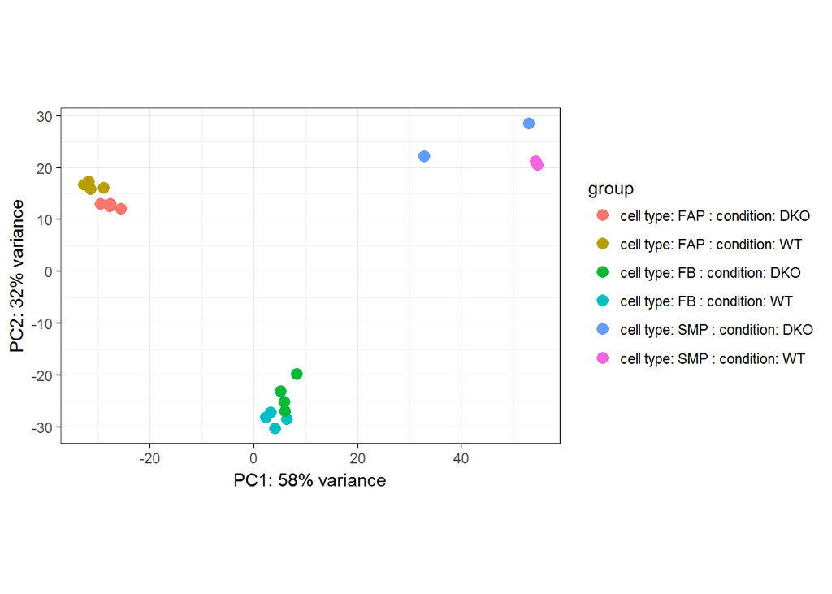

```r
dds <- DESeqDataSetFromMatrix(countData = counts,
                              colData = conditions,
                              design = ~ cells + conditions)
ind <- order(rowSums(counts(dds)), decreasing = TRUE)
dds <- dds[ind, ][1:8000,]
dds <- DESeq(dds)
vst_dds <- vst(dds)
counts.norm <- assay(vst_dds)



plotPCA(vst_dds, intgroup=c("cells", "conditions")) + theme_bw()
```

Kmeans

Используем rlog(dds) для получения логарифмированных значений экспрессии

```r
rlog_dds <- rlog(dds)
counts.log2  <- assay(rlog_dds)
```

```r
clustering <- Kmeans(counts.log2, 8, method="correlation", iter.max=20000)
```

После этого вы можете достать соотвествие каждого гена кластеру с помощью элемента листа с названием “cluster”

```r
head(clustering$cluster)
```

```
## 227753  12843  22190  12842  13179  12825
##      1      7      3      7      2      2
```

После этого от вас потребуется эту кластеризацию изобразить на хитмапе: гены должны быть отсортированы по кластерам, а столбцы сначала по клеткам, а затем по тканям.

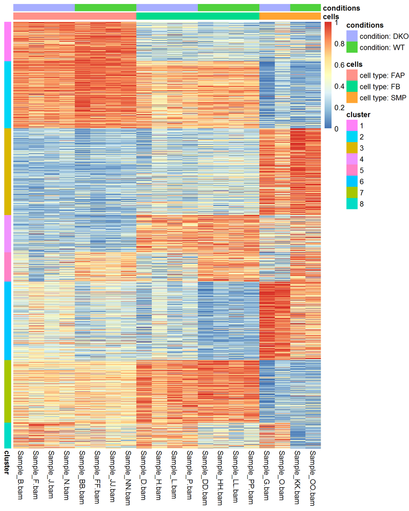

```r
to_visualise <- counts.log2[order(clustering$cluster), order(conditions$cells, conditions$conditions)]
cluster <- as.factor(clustering$cluster)
cluster <- as.data.frame(cluster)
to_visualise <- t(apply(to_visualise, 1, function(r) {
  (r - min(r)) / (max(r) - min(r))
}))


pheatmap(to_visualise,
         show_rownames = F, cluster_rows = F,
         cluster_cols=F,
         annotation_col = conditions,
         annotation_row =  cluster)
```

```r
# dev.off()
```

Отвечаю на вопросы: 1. Да, при помощи PCA можно найти аутлаер в датасете. Это будет какая-нибудь точка на графике, которая удалена от остальных. Чтобы определить конкретно, что это за наблюдение, можно воспользоваться функцией плотли (и навести указатель мыши на данный аутлаер). При помощи хитмапы, как мне кажется, найти аутлаер труднее, чем при помощи PCA. Но я сейчас запустил первую домашку, там выброс (treg_NBP_patient3) выделяется из всех.

2. Я думаю, что можем. У нас есть на pca названия групп (справа на графике - cell type + condition).

Делаем 3 сравнения

```r
cond_FB = conditions[conditions$cells == "cell type: FB",]
cond_FAP = conditions[conditions$cells == "cell type: FAP",]
cond_SMP = conditions[conditions$cells == "cell type: SMP",]


#убрать cells из дизайна - заметка

counts_FB = counts[,rownames(cond_FB)]
counts_FAP = counts[,rownames(cond_FAP)]
counts_SMP = counts[,rownames(cond_SMP)]


dds_FB <- DESeqDataSetFromMatrix(countData = counts_FB,
                              colData = cond_FB,
                              design =  ~ conditions)
ind <- order(rowSums(counts(dds_FB)), decreasing = TRUE)
dds_FB <- dds_FB[ind, ]
dds_FB <- DESeq(dds_FB)
vst_dds_FB <- vst(dds_FB)
counts.norm_FB <- assay(vst_dds_FB)





dds_FAP <- DESeqDataSetFromMatrix(countData = counts_FAP,
                              colData = cond_FAP,
                              design = ~ conditions)
ind_FAP <- order(rowSums(counts(dds_FAP)), decreasing = TRUE)
dds_FAP <- dds_FAP[ind_FAP, ]
dds_FAP <- DESeq(dds_FAP)
vst_dds_FAP <- vst(dds_FAP)
counts.norm_FAP <- assay(vst_dds_FAP)



dds_SMP <- DESeqDataSetFromMatrix(countData = counts_SMP,
                              colData = cond_SMP,
                              design = ~ conditions)
ind_SMP <- order(rowSums(counts(dds_SMP)), decreasing = TRUE)
dds_SMP <- dds_SMP[ind, ]
dds_SMP <- DESeq(dds_SMP)
vst_dds_SMP <- vst(dds_SMP)
counts.norm_SMP <- assay(vst_dds_SMP)
```

# Differential expression

```r
res_FB <- results(dds_FB)
res_FB
```

```
## log2 fold change (MAP): conditions condition: WT vs condition: DKO
## Wald test p-value: conditions condition: WT vs condition: DKO
## DataFrame with 24393 rows and 6 columns
##        baseMean log2FoldChange     lfcSE      stat       pvalue         padj
##       <numeric>      <numeric> <numeric> <numeric>    <numeric>    <numeric>
## 12843  407883.5      0.7682135 0.1221487  6.289164 3.191805e-10 1.333765e-08
## 12842  304071.6      0.6355768 0.1461274  4.349472 1.364659e-05 2.035345e-04
## 14264  253374.9      0.5035209 0.1259939  3.996392 6.431517e-05 7.926306e-04
## 21828  234361.1     -0.9505110 0.1115496 -8.520969 1.582234e-17 1.472608e-15
## 20692  189417.7      0.5116305 0.1261787  4.054808 5.017554e-05 6.358674e-04
## ...         ...            ...       ...       ...          ...          ...
## 99035         0             NA        NA        NA           NA           NA
## 99169         0             NA        NA        NA           NA           NA
## 99662         0             NA        NA        NA           NA           NA
## 99663         0             NA        NA        NA           NA           NA
## 99709         0             NA        NA        NA           NA           NA
```

```r
mcols(res_FB)$description
```

```
## [1] "mean of normalized counts for all samples"
## [2] "log2 fold change (MAP): conditions condition: WT vs condition: DKO"
## [3] "standard error: conditions condition: WT vs condition: DKO"
## [4] "Wald statistic: conditions condition: WT vs condition: DKO"
## [5] "Wald test p-value: conditions condition: WT vs condition: DKO"
## [6] "BH adjusted p-values"
```

```r
res_FB <- res_FB[order(res_FB[, 4]), ]
res_FB
```

```
## log2 fold change (MAP): conditions condition: WT vs condition: DKO
## Wald test p-value: conditions condition: WT vs condition: DKO
## DataFrame with 24393 rows and 6 columns
##        baseMean log2FoldChange      lfcSE      stat        pvalue          padj
##       <numeric>      <numeric>  <numeric> <numeric>     <numeric>     <numeric>
## 50706 31794.356      -3.223469 0.14743650 -21.86344 5.791474e-106 8.300920e-102
## 13602 23731.884      -1.637606 0.08730075 -18.75821  1.658789e-78  1.188771e-74
## 66695 10771.007      -2.717668 0.14625987 -18.58109  4.570995e-77  2.183869e-73
## 50530  1711.655      -1.847944 0.10937974 -16.89475  4.917618e-64  1.762105e-60
## 69700  5138.158      -2.011422 0.12023978 -16.72842  8.136916e-63  1.943774e-59
## ...         ...            ...        ...       ...           ...           ...
## 99035         0             NA         NA        NA            NA            NA
## 99169         0             NA         NA        NA            NA            NA
## 99662         0             NA         NA        NA            NA            NA
## 99663         0             NA         NA        NA            NA            NA
## 99709         0             NA         NA        NA            NA            NA
```

```r
# Готовим данные для Volcano plot
res_FAP <- results(dds_FAP)
res_FAP
```

```
## log2 fold change (MAP): conditions condition: WT vs condition: DKO
## Wald test p-value: conditions condition: WT vs condition: DKO
## DataFrame with 24393 rows and 6 columns
##         baseMean log2FoldChange      lfcSE       stat      pvalue       padj
##        <numeric>      <numeric>  <numeric>  <numeric>   <numeric>  <numeric>
## 227753  554360.1    -0.24074452 0.09023924 -2.6678474 0.007633892 0.04717209
## 12825   242976.4     0.37581309 0.12077308  3.1117291 0.001859951 0.01590427
## 22190   174008.8     0.04122719 0.10680533  0.3860031 0.699494400 0.85646767
## 13179   172728.2     0.05943667 0.07565565  0.7856210 0.432089560 0.68063803
## 12843   125646.1     0.17865751 0.10340459  1.7277522 0.084032658 0.25859508
## ...          ...            ...        ...        ...         ...        ...
## 98582          0             NA         NA         NA          NA         NA
## 99041          0             NA         NA         NA          NA         NA
## 99377          0             NA         NA         NA          NA         NA
## 99662          0             NA         NA         NA          NA         NA
## 99709          0             NA         NA         NA          NA         NA
```

```r
mcols(res_FAP)$description
```

```
## [1] "mean of normalized counts for all samples"
## [2] "log2 fold change (MAP): conditions condition: WT vs condition: DKO"
## [3] "standard error: conditions condition: WT vs condition: DKO"
## [4] "Wald statistic: conditions condition: WT vs condition: DKO"
## [5] "Wald test p-value: conditions condition: WT vs condition: DKO"
## [6] "BH adjusted p-values"
```

```r
res_FAP <- res_FAP[order(res_FAP[, 4]), ]
res_FAP
```

```
## log2 fold change (MAP): conditions condition: WT vs condition: DKO
## Wald test p-value: conditions condition: WT vs condition: DKO
## DataFrame with 24393 rows and 6 columns
##          baseMean log2FoldChange     lfcSE      stat        pvalue          padj
##         <numeric>      <numeric> <numeric> <numeric>     <numeric>     <numeric>
## 21828  17742.0617      -3.026273 0.1358962 -22.26901 7.381948e-110 1.010589e-105
## 214425 17272.6404      -1.969343 0.1018786 -19.33029  2.987305e-83  2.044811e-79
## 12837   3075.2070      -2.139672 0.1129720 -18.93984  5.356012e-80  2.444127e-76
## 21923   1068.0633      -2.052619 0.1168734 -17.56275  4.752020e-69  1.626379e-65
## 21857    644.2937      -1.895378 0.1257257 -15.07550  2.347242e-51  6.426748e-48
## ...           ...            ...       ...       ...           ...           ...
## 98582           0             NA        NA        NA            NA            NA
## 99041           0             NA        NA        NA            NA            NA
## 99377           0             NA        NA        NA            NA            NA
## 99662           0             NA        NA        NA            NA            NA
## 99709           0             NA        NA        NA            NA            NA
```

```r
res_SMP <- results(dds_SMP)
res_SMP
```

```
## log2 fold change (MAP): conditions condition: WT vs condition: DKO
## Wald test p-value: conditions condition: WT vs condition: DKO
## DataFrame with 24393 rows and 6 columns
##        baseMean log2FoldChange     lfcSE       stat    pvalue      padj
##       <numeric>      <numeric> <numeric>  <numeric> <numeric> <numeric>
## 12843  25707.90     0.38131821 0.3721806  1.0245516 0.3055748 0.6194342
## 12842  20055.03     0.26976923 0.3811800  0.7077213 0.4791183 0.7611407
## 14264  10306.54     0.05653945 0.4081705  0.1385192 0.8898301 0.9603507
## 21828  23460.98    -0.02249167 0.2144152 -0.1048977 0.9164570 0.9691400
## 20692  20813.49     0.21027146 0.2452578  0.8573488 0.3912522 0.6954425
## ...         ...            ...       ...        ...       ...       ...
## 99035 0.0000000             NA        NA         NA        NA        NA
## 99169 0.0000000             NA        NA         NA        NA        NA
## 99662 0.0000000             NA        NA         NA        NA        NA
## 99663 0.3065989    -0.05662991 0.1299503 -0.4357812 0.6629955        NA
## 99709 0.0000000             NA        NA         NA        NA        NA
```

```r
mcols(res_SMP)$description
```

```
## [1] "mean of normalized counts for all samples"
## [2] "log2 fold change (MAP): conditions condition: WT vs condition: DKO"
## [3] "standard error: conditions condition: WT vs condition: DKO"
## [4] "Wald statistic: conditions condition: WT vs condition: DKO"
## [5] "Wald test p-value: conditions condition: WT vs condition: DKO"
## [6] "BH adjusted p-values"
```

```r
res_SMP <- res_SMP[order(res_SMP[, 4]), ]
res_SMP
```

```
## log2 fold change (MAP): conditions condition: WT vs condition: DKO
## Wald test p-value: conditions condition: WT vs condition: DKO
## DataFrame with 24393 rows and 6 columns
##         baseMean log2FoldChange     lfcSE      stat       pvalue         padj
##        <numeric>      <numeric> <numeric> <numeric>    <numeric>    <numeric>
## 433855  314.0533      -4.696186 0.2874864 -16.33533 5.533012e-60 3.292695e-56
## 80888   900.4582      -2.507567 0.1832108 -13.68679 1.217764e-42 3.623458e-39
## 15368  4756.3165      -2.674004 0.2065641 -12.94516 2.502554e-38 5.957079e-35
## 20198   400.5412      -2.999600 0.2525531 -11.87711 1.556608e-32 3.087791e-29
## 11622   682.2018      -2.308136 0.2013853 -11.46129 2.064069e-30 3.509507e-27
## ...          ...            ...       ...       ...          ...          ...
## 98752          0             NA        NA        NA           NA           NA
## 99035          0             NA        NA        NA           NA           NA
## 99169          0             NA        NA        NA           NA           NA
## 99662          0             NA        NA        NA           NA           NA
## 99709          0             NA        NA        NA           NA           NA
```

Самый обычный способ визуализировать данные дифф.экспрессии – это volcano plot. По оси x мы будем откладывать log fold change, а по y - adjusted p value.

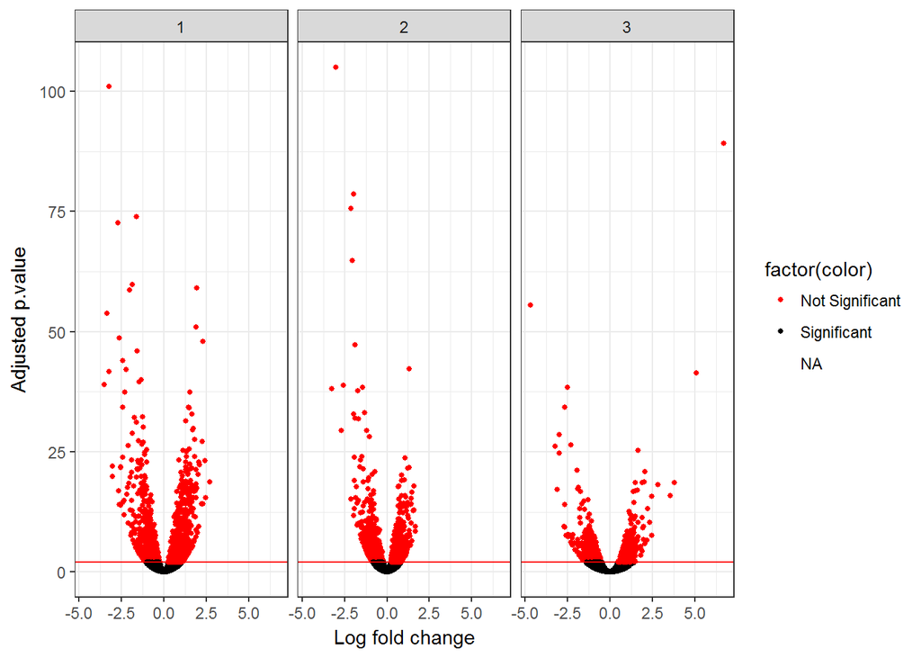

```r
# Строим Volcano plot

gdata1 <- data.frame(
  x=res_FB$log2FoldChange,
  y=-log10(res_FB$padj),
  name_ =  "1"
)

gdata2 <- data.frame(
  x=res_FAP$log2FoldChange,
  y=-log10(res_FAP$padj),
  name_ =  "2"
)


gdata3 <- data.frame(
  x=res_SMP$log2FoldChange,
  y=-log10(res_SMP$padj),
  name_ =  "3"
)


gdata4 <- rbind(gdata1, gdata2, gdata3)
res4 <- rbind(res_FB, res_FAP, res_SMP)

gdata4 <- gdata4 %>%
  mutate(color = ifelse(res4$padj > 0.01,
                        yes = "Significant",
                        no =  "Not Significant"))



ggplot(data=gdata4, aes(x=x, y=y)) +
  geom_point(aes(color = factor(color)), size=1) + theme_bw()  +
  xlab("Log fold change") +
  ylab("Adjusted p.value") +
  geom_hline(yintercept=2, color='red') +
  facet_grid(. ~ name_) +
  scale_color_manual(values = c("Significant" = "#000000",
                                "Not Significant" = "#ff0000")) # change colors
```

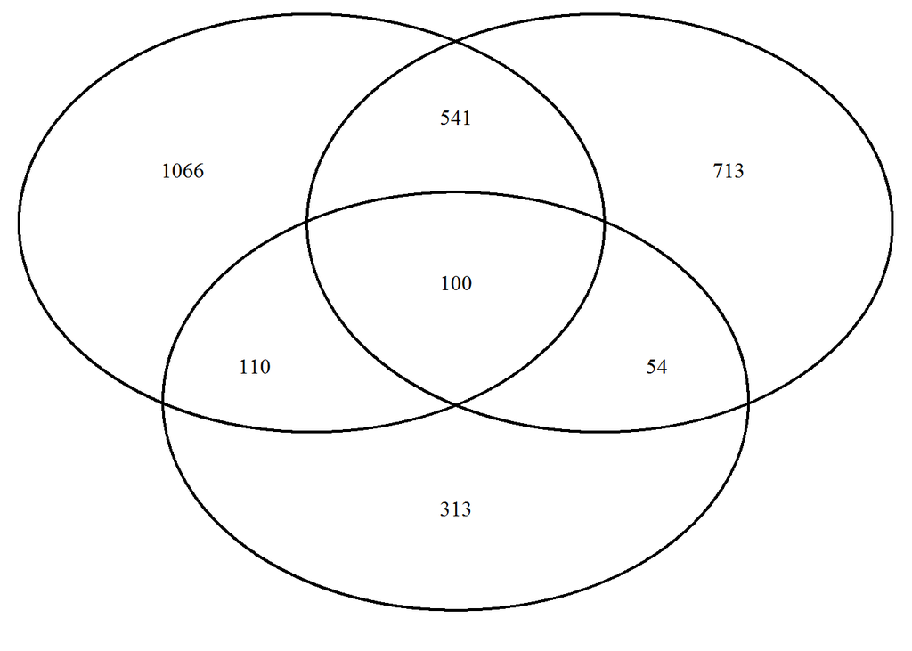

[output not shown]

```r
#Последнее задание, строим Ven diagrams

resone <- res_FB[which(res_FB$padj < 0.01),]
restwo <- res_FAP[which(res_FAP$padj < 0.01),]
resthree <- res_SMP[which(res_SMP$padj < 0.01),]
commongenes <- intersect(rownames(resone), rownames(restwo))
commongenes2 <- intersect(rownames(resthree), rownames(restwo))

commongenes22 <- intersect(rownames(resone), rownames(resthree))

commongenes3 <- intersect(commongenes, commongenes22)

commongenes4 <- intersect(commongenes3, commongenes2)
draw.triple.venn(area1 = length(rownames(resone)), area2 = length(rownames(restwo)),
                 area3 = length(rownames(resthree)),
                 n12 = length(commongenes),
                 n23 = length(commongenes2),
                 n13 = length(commongenes22),
                 n123 = length(commongenes4))
```